# `ggplot` 연습문제

`learningSpoonsR@gmail.com

- `Rmd`파일을 이메일로 제출해주세요.

## 1. `hwy`와 `cyl`을 이용해서 산점도(scatterplot)를 그려보세요. `cyl`과 같은 discrete variable을 이용해서 산점도를 그리면 어떤 일이 벌어지나요?

```r
ggplot(mpg, aes(x = cyl, y = hwy)) + geom_point()
ggplot(mpg, aes(x = cyl, y = hwy)) + geom_boxplot()
ggplot(mpg, aes(x = as.factor(cyl), y = hwy)) + geom_boxplot()
ggplot(mpg, aes(x = as.factor(cyl), y = hwy)) + geom_violin()
```

[output not shown]

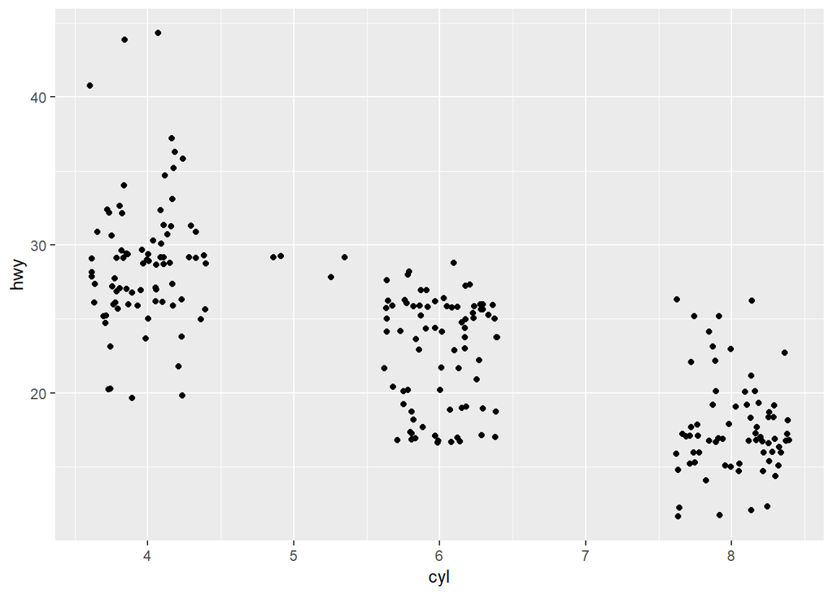

```r
ggplot(mpg, aes(x=cyl, y=hwy)) + geom_point(position = "jitter")
```

## 2. 아래 명령은 무엇이 잘못되었나요? 모든점을 파란색으로 그리려면 어떻게 해야하나요?

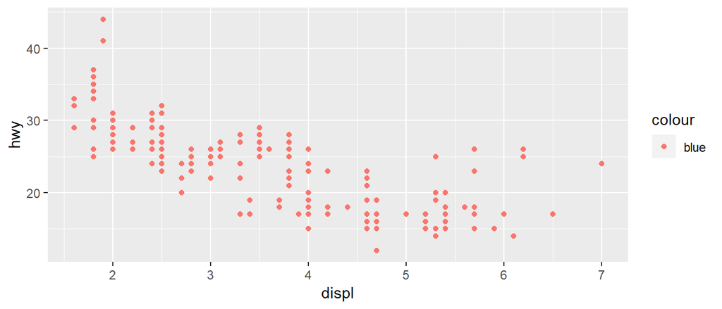

```r
ggplot(data = mpg) +
  geom_point(mapping = aes(x = displ, y = hwy, color = "blue"))
```

정답은 아래의 코드에 있습니다. 무엇이 다르나요?

```r
ggplot(data = mpg) +
  geom_point(mapping = aes(x = displ, y = hwy), color = "blue")
```

- 이해되시나요? 즉, `aes()`에는 데이터마다 달라지는 특성을 넣고, `geom_XXXXX`에는 데이터에 상관없이 공통적으로 적용되는 특성을 넣어줘야 합니다.
- `aes`바깥에, 그리고 `geom_`의 안쪽에 color를 넣으면 데이터 수치와 상관없이 모두에게 적용됩니다.

## 3. `mpg`의 어떤 변수가 categorical입니까? 어떤 변수가 continuous입니까? (Hint: `summary()`, `length(unique())`)

```r
summary(mpg)
```

```
##  manufacturer          model               displ            year
##  Length:234         Length:234         Min.   :1.600   Min.   :1999
##  Class :character   Class :character   1st Qu.:2.400   1st Qu.:1999
##  Mode  :character   Mode  :character   Median :3.300   Median :2004
##                                        Mean   :3.472   Mean   :2004
##                                        3rd Qu.:4.600   3rd Qu.:2008
##                                        Max.   :7.000   Max.   :2008
##       cyl           trans               drv                 cty
##  Min.   :4.000   Length:234         Length:234         Min.   : 9.00
##  1st Qu.:4.000   Class :character   Class :character   1st Qu.:14.00
##  Median :6.000   Mode  :character   Mode  :character   Median :17.00
##  Mean   :5.889                                         Mean   :16.86
##  3rd Qu.:8.000                                         3rd Qu.:19.00
##  Max.   :8.000                                         Max.   :35.00
##       hwy             fl               class
##  Min.   :12.00   Length:234         Length:234
##  1st Qu.:18.00   Class :character   Class :character
##  Median :24.00   Mode  :character   Mode  :character
##  Mean   :23.44
##  3rd Qu.:27.00
##  Max.   :44.00
```

- 위의 결과에서 Min, Mean등이 나온 것은 모두 continuous (numeric) 입니다.

## 4. Continuous 변수로 `facet`을 하면 어떤 일이 벌어질까요?

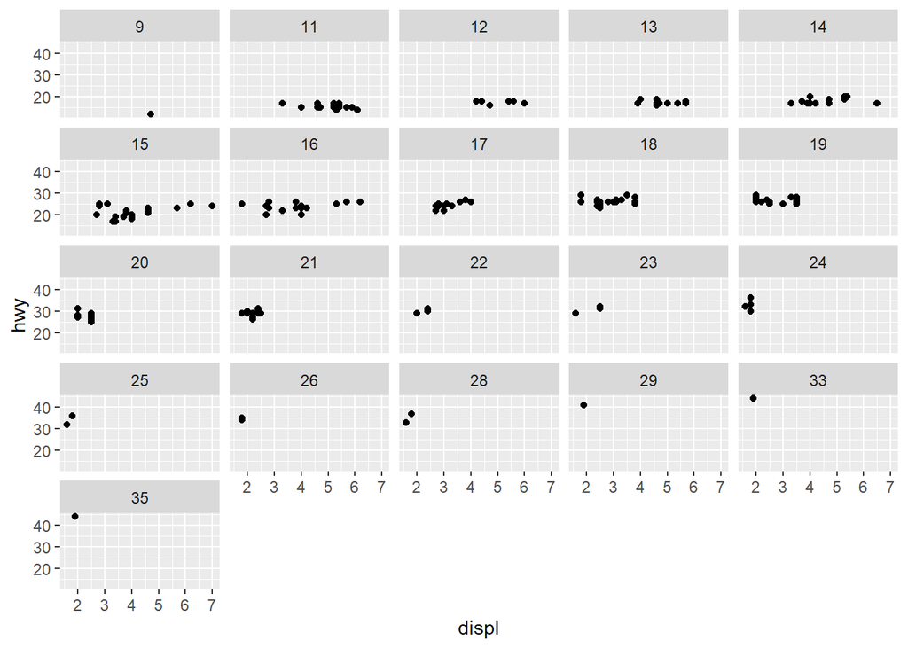

```r
ggplot(data = mpg) +
  geom_point(mapping = aes(x = displ, y = hwy)) +
  facet_wrap(~ cty)
```

- 위와 같이 `cty`로 `facet`을 하면 `cty`의 모든 값에 대해서 그래프가 분할되어 그려집니다. `cty`의 본질은 연속변수이지만, 데이터가 정수로 반올림되어 있기 때문에 그림이 그려지기는 합니다.
- 그러나 `cty`로 `facet`을 해서 얻게되는 이점은 거의 없겠죠?
- 만약에 `cty`가 소수점까지 있는 경우라면 어떻게 될까요? 이를 알아보기 위해서 아래와 같이 실험을 했습니다. 아래 코드는 `cty`에 0에서 1사이의 랜덤한 숫자를 더해주어서 `cty_float`이라는 변수를 만들고 그걸로 `facet`을 합니다. 아래 코드를 실제로 실행하면 아주 오랜 시간동안 프로세스해서 이상한 그림이 나오는 것을 알 수 있습니다.
- 즉, facet을 할때는 변수의 본질이 categorical 변수이거나 `length(unique())`를 실행해서 값이 작은 경우에만 사용하는 것이 바람직합니다.

```r
mpg$cty_float <- mpg$cty + runif(length(mpg$cty))
ggplot(data = mpg) +
  geom_point(mapping = aes(x = displ, y = hwy)) +
  facet_wrap(~ cty_float)
```